```python
import numpy as np
import matplotlib.pyplot as plt
from numba import jit
from scipy.optimize import curve_fit
```

On utilise la discrétisation du laplacien $\Delta V = 0$ $$ \Delta V = \frac{\partial^2 V}{\partial x^2}+\frac{\partial^2 V}{\partial y^2} \simeq \frac{V_{i+1,j} -2 V_{i,j} + V_{i-1,j}}{(\Delta x)^2}+\frac{V_{i,j+1} -2 V_{i,j} + V_{i,j-1}}{(\Delta y)^2}=0$$
En isolant $V_{i,j}$, on trouve : $$ V_{i,j} = \frac{\frac{(\Delta y)^2}{(\Delta x)^2}(V_{i+1,j} + V_{i-1,j}) +V_{i,j+1} +V_{i,j-1}}{2(\frac{(\Delta y)^2}{(\Delta x)^2}+1)} $$
Si on utilise une maille carré, i.e. $(\Delta y)^2 =(\Delta x)^2$, on trouve : $$ V_{i,j} = \frac{1}{4}(V_{i+1,j} + V_{i-1,j} +V_{i,j+1} +V_{i,j-1}) $$

Avec les conditions de Neumann suivantes :  
${\displaystyle \frac{\partial V}{\partial x} =0 }$ sur le bord gauche et droit.  
${ \displaystyle \frac{\partial V}{\partial y} =0 }$ à gauche et à droite de l'ouverture.  
$V=V_1$ en haut.  
$V=0$ en bas.

# Code de base pour le calcul du Laplacien

### On execute le programme en premier avec des boucles, pour comprendre le système

```python
N=100 # Taille du réseau.
V=np.zeros([N+1,N+1]) #Initialisation du réseau.
V[1:N-1,1:N-1] # V avec une ligne en bas et en haut en moins ainsi que une colonne à gauche et à droite.

Eps= 1e-3
Ecart=1.0

while Ecart>Eps:
    Vprec=V.copy()
    V[99,:]=100 # Toutes les colonnes, et la ligne 99
    for i in np.arange(1,N,1):
        for j in np.arange(1,N,1):
            V[i,j]=0.25*(V[i+1,j]+V[i-1,j]+V[i,j+1]+V[i,j-1])
            V[:,1]=V[:,0]
            V[:,99]=V[:,100]
    Ecart = np.max(np.abs(V-Vprec))
```

### On effectue ensuite le calcul sous forme matricielle pour gagner en rapidité

```python
N=100 # Taille du réseau.
V=np.zeros([N+1,N+1]) #Initialisation du réseau.
#V[1:99,1:99]=0.25*(V[2:100,1:99]+V[0:98,1:99]+V[1:99,2:100]+V[1:99,0:98])
#V[1:N-1,1:N-1]=0.25*(V[2:N,1:N-1]+V[0:N-2,1:N-1]+V[1:N-1,2:N]+V[1:N-1,0:N-2])

N=100 # Taille du réseau.
V=np.zeros([N+1,N+1]) #Initialisation du réseau.
V[1:N-1,1:N-1] # V avec une ligne en bas et en haut en moins ainsi que une colonne à gauche et à droite.

Eps= 1e-10
Ecart=1.0
i=np.arange(1,8)
Size=np.zeros(len(i))
Field=np.zeros(len(i))
while Ecart>Eps:
    Vprec=V.copy()
    V[N,:]=100 # Toutes les colonnes, et la ligne 99
    V[:,0]=V[:,1] #Bord Gauche
    V[:,100]=V[:,99] #Bord Droit
    V[1:N,1:N]=0.25*(V[2:N+1,1:N]+V[0:N-1,1:N]+V[1:N,2:N+1]+V[1:N,0:N-1])
    V[0,0:45]= V[1,0:45]
    V[0,55:N]= V[1,55:N]
    Ecart = np.max(np.abs(V-Vprec))
```

# Plot : Courbe equipotentielle et ligne de courant

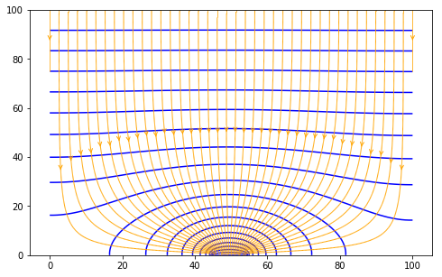

```python
x = np.arange(0,N+1,1)
y = np.arange(0,N+1,1)
X,Y = np.meshgrid(x,y)

A=np.linspace(0,N,40)
B = 75*np.ones(len(A))
seed_points = np.array([A,B])


Ey,Ex = np.gradient(V)

Ey=-Ey
Ex=-Ex
plt.figure(figsize=(8,5))
plt.contour(X,Y,V,20,colors='b')
plt.streamplot(X, Y, Ex, Ey,linewidth=1,arrowstyle='->',density=10,start_points=seed_points.T,color='orange')
```

```python
np.sum(Ey[100,:])
```

```
-61.06425496294564
```

# On essaye d'utiliser Numba pour gagner enore de la vitesse

```python
@jit
def Calcul(V):
    N=100 # Taille du réseau.
    #Initialisation du réseau.
    #V[1:99,1:99]=0.25*(V[2:100,1:99]+V[0:98,1:99]+V[1:99,2:100]+V[1:99,0:98])
    #V[1:N-1,1:N-1]=0.25*(V[2:N,1:N-1]+V[0:N-2,1:N-1]+V[1:N-1,2:N]+V[1:N-1,0:N-2])

    Eps= 1e-10
    Ecart=1.0
    i=np.arange(1,8)
    Size=np.zeros(len(i))
    Field=np.zeros(len(i))
    while Ecart>Eps:
        Vprec=V.copy()
        V[N,:]=100 # Toutes les colonnes, et la ligne 99
        V[:,0]=V[:,1] #Bord Gauche
        V[:,100]=V[:,99] #Bord Droit
        V[1:N,1:N]=0.25*(V[2:N+1,1:N]+V[0:N-1,1:N]+V[1:N,2:N+1]+V[1:N,0:N-1])
        V[0,0:45]= V[1,0:45]
        V[0,55:N]= V[1,55:N]
        Ecart = np.max(np.abs(V-Vprec))
    return V
```

```python
V=np.zeros([N+1,N+1])
V=Calcul(V)
```

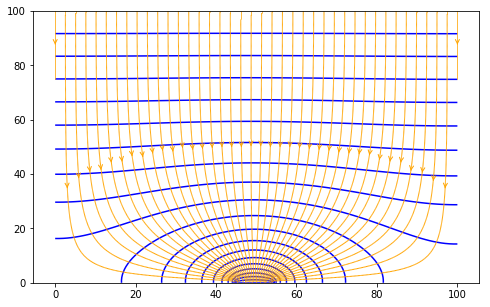

```python
N=100

x = np.arange(0,N+1,1)
y = np.arange(0,N+1,1)
X,Y = np.meshgrid(x,y)

A=np.linspace(0,N,40)
B = 75*np.ones(len(A))
seed_points = np.array([A,B])


Ey,Ex = np.gradient(V)

Ey=-Ey
Ex=-Ex
plt.figure(figsize=(8,5))
plt.contour(X,Y,V,20,colors='b')
plt.streamplot(X, Y, Ex, Ey,linewidth=1,arrowstyle='->',density=10,start_points=seed_points.T,color='orange')
```

Cette méthode complique un peu le programme et ne fais pas gagner énormément en vitesse, on l'évitera par la suite

# Boucle pour calcul résistance

```python
#LOOP FOR RESISTANCE

k=0
i=2*np.arange(1,26)
Size=i
Field=np.zeros(len(i))
for HalfSize in i:
    N=100 # Taille du réseau.
    V=np.zeros([N+1,N+1]) #Initialisation du réseau.
    #V[1:N-1,1:N-1] # V avec une ligne en bas et en haut en moins ainsi que une colonne à gauche et à droite.
    Eps= 1e-10
    Ecart=1.0
    A=50+HalfSize
    B=50-HalfSize
    while Ecart>Eps:
        Vprec=V.copy()
        V[N,:]=100 # Toutes les colonnes, et la ligne 99
        V[:,0]=V[:,1] #Bord Gauche
        V[:,100]=V[:,99] #Bord Droit
        V[1:N,1:N]=0.25*(V[2:N+1,1:N]+V[0:N-1,1:N]+V[1:N,2:N+1]+V[1:N,0:N-1])
        V[0,0:B]= V[1,0:B]
        V[0,A:N]= V[1,A:N]
        Ecart = np.max(np.abs(V-Vprec))
    Ey,Ex = np.gradient(V)
    Field[k]=np.sum(Ey[100,:])
    k=k+1
```

# Enregistrement des données

```python
np.savetxt("Data_Loop_Ouverture_Seul_Res.txt",[Size,Field],header=" Il faut faire : [Size,Field]=np.loadtxt('Data_Loop_Ouverture_Seul_Res.txt')",comments="#")
[Size1,Field1]=np.loadtxt('Data_Loop_Ouverture_Seul_Res.txt')
```

[output not shown]

# Plot de la resistance en fonction de l'ouverture + Regression

```
[2.79518021 0.23361439]
```

[figure not shown]

```python
#plt.plot(Size, Field)

def Reg(x, a, b):
    return a/(x**b)

popt1, pcov1 = curve_fit(Reg, Size, Res)
plt.plot(Size, Reg(Size, *popt1),label="Regression")

print(popt1)
Res=100*(1/Field)
plt.plot(Size,Res,linewidth=1,color='k',label="Resistance")
plt.xlabel(r'Ouverture (en %)')
plt.ylabel(r'Resistance (unités arbitraires)')
plt.title("Resistance en fonction de l'ouverture")
plt.legend()
```

# Calcul résistance avec le potentiel plus près de la constriction.

```python
#LOOP FOR RESISTANCE 2

N=100 # Taille du réseau.
V=np.zeros([N+1,N+1]) #Initialisation du réseau.
#V[1:N-1,1:N-1] # V avec une ligne en bas et en haut en moins ainsi que une colonne à gauche et à droite.
Eps= 1e-10
Ecart=1.0

A=50+10
B=50-10
while Ecart>Eps:
    Vprec=V.copy()
    # V[N,:]=100 # Toutes les colonnes, et la ligne 99
    V[:,0]=V[:,1] #Bord Gauche
    V[:,100]=V[:,99] #Bord Droit

    V[1:N,1:N]=0.25*(V[2:N+1,1:N]+V[0:N-1,1:N]+V[1:N,2:N+1]+V[1:N,0:N-1])

    V[0,0:B]= V[1,0:B]
    V[0,A:N]= V[1,A:N]
    V[10,:]= V[11,:]
    V[10,:]=100
    Ecart = np.max(np.abs(V-Vprec))
```

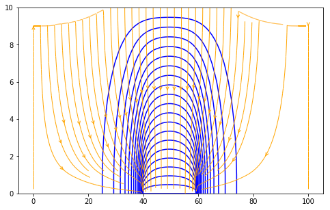

```python
x = np.arange(0,N+1,1)
y = np.arange(0,N+1,1)
X,Y = np.meshgrid(x,y)

A=np.linspace(0,N,40)
B = 9*np.ones(len(A))
seed_points = np.array([A,B])


Ey,Ex = np.gradient(V)

Ey=-Ey
Ex=-Ex
plt.figure(figsize=(8,5))
plt.ylim([0,10])
plt.contour(X,Y,V,20,colors='b')
plt.streamplot(X, Y, Ex, Ey,linewidth=1,arrowstyle='->',density=10,start_points=seed_points.T,color='orange')
```

```python
np.sum(Ey[9,:])
```

```
-269.54762259054553
```

# Calcul résistance de constriction avec une hauteur de 10 en terme de maille

```python
#LOOP FOR RESISTANCE 2

k=0
i=2*np.arange(1,26)
Size=2*i
Field=np.zeros(len(i))
for HalfSize in i:
    N=100 # Taille du réseau.
    V=np.zeros([N+1,N+1]) #Initialisation du réseau.
    #V[1:N-1,1:N-1] # V avec une ligne en bas et en haut en moins ainsi que une colonne à gauche et à droite.
    Eps= 1e-10
    Ecart=1.0
    A=50+HalfSize
    B=50-HalfSize
    while Ecart>Eps:
        Vprec=V.copy()
        # V[N,:]=100 # Toutes les colonnes, et la ligne 99
        V[:,0]=V[:,1] #Bord Gauche
        V[:,100]=V[:,99] #Bord Droit

        V[1:N,1:N]=0.25*(V[2:N+1,1:N]+V[0:N-1,1:N]+V[1:N,2:N+1]+V[1:N,0:N-1])

        V[0,0:B]= V[1,0:B]
        V[0,A:N]= V[1,A:N]
        V[10,:]= V[11,:]
        V[10,:]=100
        Ecart = np.max(np.abs(V-Vprec))
    Ey,Ex = np.gradient(V)
    Field[k]=np.sum(Ey[9,:])
    k=k+1
```

```python
Field
```

```
array([ 101.69074166,  147.5783356 ,  189.01661692,  229.42108261,
        269.54762259,  309.60002826,  349.63743915,  389.67910944,
        429.73375293,  469.80815269,  509.9099138 ,  550.0485137 ,
        590.23570008,  630.48522002,  670.81118743,  711.22344683,
        751.71650377,  792.24511106,  832.67306471,  872.67070249,
        911.52270284,  947.80889566,  979.00150023, 1001.29039354,
       1010.        ])
```

```
[4.93520536 1.        ]
```

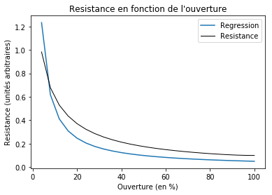

```python
#plt.plot(Size, Field)

def Reg(x, a, b):
    return a/(x)

popt1, pcov1 = curve_fit(Reg, Size, Res)
plt.plot(Size, Reg(Size, *popt1),label="Regression")

print(popt1)
Res=100*(1/Field)
plt.plot(Size,Res,linewidth=1,color='k',label="Resistance")
plt.xlabel(r'Ouverture (en %)')
plt.ylabel(r'Resistance (unités arbitraires)')
plt.title("Resistance en fonction de l'ouverture")
plt.legend()
```

# Calcul résistance de constriction avec une hauteur de 5 en terme de maille

```python
#LOOP FOR RESISTANCE 2

k=0
i=2*np.arange(1,26)
Size=2*i
Field=np.zeros(len(i))
for HalfSize in i:
    N=100 # Taille du réseau.
    V=np.zeros([N+1,N+1]) #Initialisation du réseau.
    #V[1:N-1,1:N-1] # V avec une ligne en bas et en haut en moins ainsi que une colonne à gauche et à droite.
    Eps= 1e-10
    Ecart=1.0
    A=50+HalfSize
    B=50-HalfSize
    while Ecart>Eps:
        Vprec=V.copy()
        # V[N,:]=100 # Toutes les colonnes, et la ligne 99
        V[:,0]=V[:,1] #Bord Gauche
        V[:,100]=V[:,99] #Bord Droit

        V[1:N,1:N]=0.25*(V[2:N+1,1:N]+V[0:N-1,1:N]+V[1:N,2:N+1]+V[1:N,0:N-1])

        V[0,0:B]= V[1,0:B]
        V[0,A:N]= V[1,A:N]
        V[5,:]= V[6,:]
        V[5,:]=100
        Ecart = np.max(np.abs(V-Vprec))
    Ey,Ex = np.gradient(V)
    Field[k]=np.sum(Ey[4,:])
    k=k+1
```

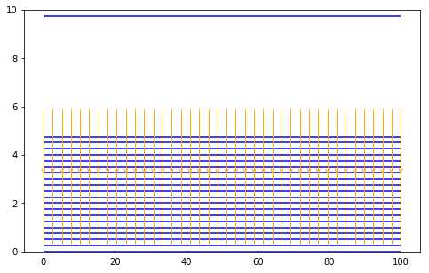

```python
x = np.arange(0,N+1,1)
y = np.arange(0,N+1,1)
X,Y = np.meshgrid(x,y)

A=np.linspace(0,N,40)
B = 4*np.ones(len(A))
seed_points = np.array([A,B])


Ey,Ex = np.gradient(V)

Ey=-Ey
Ex=-Ex
plt.figure(figsize=(8,5))
plt.ylim([0,10])
plt.contour(X,Y,V,20,colors='b')
plt.streamplot(X, Y, Ex, Ey,linewidth=1,arrowstyle='->',density=10,start_points=seed_points.T,color='orange')
```

```
[4.93520536 1.        ]
```

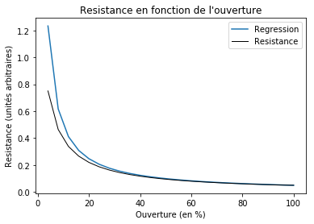

```python
#plt.plot(Size, Field)

def Reg(x, a, b):
    return a/(x)

popt1, pcov1 = curve_fit(Reg, Size, Res)
plt.plot(Size, Reg(Size, *popt1),label="Regression")

print(popt1)
Res=100*(1/Field)
plt.plot(Size,Res,linewidth=1,color='k',label="Resistance")
plt.xlabel(r'Ouverture (en %)')
plt.ylabel(r'Resistance (unités arbitraires)')
plt.title("Resistance en fonction de l'ouverture")
plt.legend()
```

# Plusieurs ouvertures en maille carré

```python
N=100 # Taille du réseau.
V=np.zeros([N+1,N+1]) #Initialisation du réseau.
#V[1:99,1:99]=0.25*(V[2:100,1:99]+V[0:98,1:99]+V[1:99,2:100]+V[1:99,0:98])
#V[1:N-1,1:N-1]=0.25*(V[2:N,1:N-1]+V[0:N-2,1:N-1]+V[1:N-1,2:N]+V[1:N-1,0:N-2])

N=100 # Taille du réseau.
V=np.zeros([N+1,N+1]) #Initialisation du réseau.
V[1:N-1,1:N-1] # V avec une ligne en bas et en haut en moins ainsi que une colonne à gauche et à droite.

Eps= 1e-10
Ecart=1.0
i=np.arange(1,8)
Size=np.zeros(len(i))
Field=np.zeros(len(i))
while Ecart>Eps:
    Vprec=V.copy()
    V[N,:]=100 # Toutes les colonnes, et la ligne 99
    V[:,0]=V[:,1] #Bord Gauche
    V[:,100]=V[:,99] #Bord Droit
    V[1:N,1:N]=0.25*(V[2:N+1,1:N]+V[0:N-1,1:N]+V[1:N,2:N+1]+V[1:N,0:N-1])
    V[0,0:10]= V[1,0:10]
    V[0,30:70]= V[1,30:70]
    V[0,90:100]= V[1,90:100]
    Ecart = np.max(np.abs(V-Vprec))
```

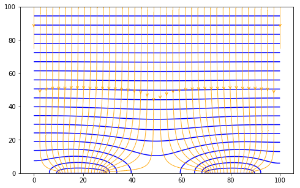

```python
x = np.arange(0,N+1,1)
y = np.arange(0,N+1,1)
X,Y = np.meshgrid(x,y)

A=np.linspace(0,N,40)
B = 75*np.ones(len(A))
seed_points = np.array([A,B])


Ey,Ex = np.gradient(V)

Ey=-Ey
Ex=-Ex
plt.figure(figsize=(8,5))
plt.contour(X,Y,V,20,colors='b')
plt.streamplot(X, Y, Ex, Ey,linewidth=1,arrowstyle='->',density=10,start_points=seed_points.T,color='orange')
```

# Maille rectangulaire

```python
N=50 # Nombre de ligne
M=200 # Nombre de colonne
V=np.zeros([N+1,M+1]) #Initialisation du réseau.
#V[1:99,1:99]=0.25*(V[2:100,1:99]+V[0:98,1:99]+V[1:99,2:100]+V[1:99,0:98])
#V[1:N-1,1:N-1]=0.25*(V[2:N,1:N-1]+V[0:N-2,1:N-1]+V[1:N-1,2:N]+V[1:N-1,0:N-2])

ParMaille=1#(N/M)**2
Eps= 1e-10
Ecart=1.0
i=np.arange(1,8)
Size=np.zeros(len(i))
Field=np.zeros(len(i))
while Ecart>Eps:
    Vprec=V.copy()
    V[N,:]=100 # Toutes les colonnes, et la ligne 99
    V[:,0]=V[:,1] #Bord Gauche
    V[:,M]=V[:,M-1] #Bord Droit

    V[1:N,1:M]=(1/(2*(ParMaille+1)))*(ParMaille*(V[2:N+1,1:M]+V[0:N-1,1:M])+V[1:N,2:M+1]+V[1:N,0:M-1])

    V[0,0:70]= V[1,0:70]
    V[0,130:M]= V[1,130:M]
    Ecart = np.max(np.abs(V-Vprec))
```

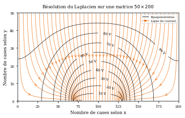

```python
x = np.arange(0,M+1,1)
y = np.arange(0,N+1,1)
X,Y = np.meshgrid(x,y)

A=np.linspace(2,M-2,40)
B = (N-1)*np.ones(len(A))
seed_points = np.array([A,B])


Ey,Ex = np.gradient(V)

Ey=-Ey
Ex=-Ex
%matplotlib inline
plt.rc('text', usetex=False)
plt.rc('font', family='serif')
#1 inch equals to 2.54 cm
fig=plt.figure(figsize=(15/2.54,(9/16)*(15/2.54)))

plt.streamplot(X, Y, Ex, Ey,linewidth=0.75,arrowstyle='->',density=10,start_points=seed_points.T,color="#ef6700")

equ=plt.contour(X,Y,V,10,linewidths=0.7,linestyles="-",colors="k")
plt.clabel(equ, fontsize=7, inline=1,inline_spacing=10,fmt='%1.0f'+" V")

plt.plot([0],[0],label="Equipotentielles",linestyle='-',linewidth=0.9,color="k")
plt.plot([0],[0],label="Ligne de courant",linestyle='-',marker=">",markersize=4,linewidth=0.9,color="#ef6700")
plt.xlabel(r"Nombre de cases selon x",fontsize = 9)
plt.ylabel(r"Nombre de cases selon y",fontsize = 9)
plt.title(r"Résolution du Laplacien sur une matrice $50 \times 200$ ",fontsize = 9,pad=10)
plt.rc('xtick', labelsize=7)
plt.rc('ytick', labelsize=7)
plt.legend(prop={'size': 6})
```

```python
fig.savefig('C:/Users/antoi/Documents/Stage_IKOS/Memoire/img/holm_matlab_eq.eps')
```

```python
15/2.54
```

```
5.905511811023622
```

##### np.arange(0,M+1,1)

# Boucle pour la résistance dans le cas de la maille rectangulaire

```python
k=0
i=4*np.arange(1,26)
Size=i #Ouverture en rayon
Field=np.zeros(len(i))

for HalfSize in i:
    N=2 # Nombre de ligne
    M=200 # Nombre de colonne
    V=np.zeros([N+1,M+1]) #Initialisation du réseau.

    ParMaille=1#(N/M)**2
    Eps= 1e-10
    Ecart=1.0
    while Ecart>Eps:
        Vprec=V.copy()
        V[N,:]=100 # Toutes les colonnes, et la ligne 99
        V[:,0]=V[:,1] #Bord Gauche
        V[:,M]=V[:,M-1] #Bord Droit

        V[1:N,1:M]=(1/(2*(ParMaille+1)))*(ParMaille*(V[2:N+1,1:M]+V[0:N-1,1:M])+V[1:N,2:M+1]+V[1:N,0:M-1])

        V[0,0:(100-HalfSize)]= V[1,0:(100-HalfSize)]
        V[0,(100+HalfSize):M]= V[1,(100+HalfSize):M]
        Ecart = np.max(np.abs(V-Vprec))

    Ey,Ex = np.gradient(V)
    Field[k]=np.sum(Ey[0,(100-HalfSize):(100+HalfSize)])
    k=k+1
```

```python
np.savetxt("Rect_Res_5_200.txt",[Size,Field],header=" Il faut faire : [Size,Field]=np.loadtxt('Rect_Res_5_200.txt')",comments="#")
```

[figure not shown]

```python
Res=100*((1/Field))
def Reg(x, a, b):
    return 1/(a*(x))

popt1, pcov1 = curve_fit(Reg, Size, Res)

FigLength=0.8 #Pourcentage de la page
#fig=plt.figure(figsize=(6,3))
fig=plt.figure(figsize=(15*FigLength/2.54,(9/16)*(15/2.54)))
plt.rc('text', usetex=True)
plt.rc('font', family='serif')
plt.plot(Size, Reg(Size, *popt1),label=r"Regression en $(ax)^{-1}$",linewidth=0.8)
plt.scatter(Size,Res,s=10,color='k',label="Po")
plt.xlabel(r'Rayon par rapport au centre ',fontsize=9)
plt.ylabel(r'Resistance (unités arbitraires)',fontsize=9)
plt.title(r"Resistance en fonction de l'ouverture pour une matrice $2\times 200$",fontsize=9)
plt.legend(prop={'size': 6})
```

```python
fig.savefig('C:/Users/antoi/Documents/Stage_IKOS/Memoire/img/Res_2_200.eps')
```

# Tracer plusieurs courbes pour voir convergence vers résistance de constriction

```python
k=0
i=4*np.arange(1,26)
Size=2*i
Field=np.zeros(len(i))
Height=np.flip(np.arange(5,100,10))
AllField=np.zeros([len(Height),len(Field)])

y=0
for N in Height:
    k=0
    i=4*np.arange(1,26)
    Size=2*i
    Field=np.zeros(len(i))
    for HalfSize in i:
        #N=5 # Nombre de ligne
        M=200 # Nombre de colonne
        V=np.zeros([N+1,M+1]) #Initialisation du réseau.

        ParMaille=1#(N/M)**2
        Eps= 1e-10
        Ecart=1.0
        while Ecart>Eps:
            Vprec=V.copy()
            V[N,:]=100 # Toutes les colonnes, et la ligne 99
            V[:,0]=V[:,1] #Bord Gauche
            V[:,M]=V[:,M-1] #Bord Droit

            V[1:N,1:M]=(1/(2*(ParMaille+1)))*(ParMaille*(V[2:N+1,1:M]+V[0:N-1,1:M])+V[1:N,2:M+1]+V[1:N,0:M-1])

            V[0,0:(100-HalfSize)]= V[1,0:(100-HalfSize)]
            V[0,(100+HalfSize):M]= V[1,(100+HalfSize):M]
            Ecart = np.max(np.abs(V-Vprec))

        Ey,Ex = np.gradient(V)
        Field[k]=np.sum(Ey[0,(100-HalfSize):(100+HalfSize)])
        k=k+1
    AllField[y]=Field
    y=y+1
```

```python
np.savetxt("AllField_Res_AllField.txt",[AllField[0], AllField[1], AllField[2], AllField[3], AllField[4], AllField[5], AllField[6], AllField[7], AllField[8], AllField[9]],header=" Il faut faire : [AllField[0], AllField[1], AllField[2], AllField[3], AllField[4], AllField[5], AllField[6], AllField[7], AllField[8], AllField[9]]=np.loadtxt('AllField_Res.txt')",comments="#")
np.savetxt("AllField_Res_Size_Field.txt",[Size,Field],header=" Il faut faire : [Size,Field]=np.loadtxt('AllField_Res.txt')",comments="#")
np.savetxt("AllField_Res_Size_Height.txt",Height,header=" Il faut faire : Height=np.loadtxt('AllField_Res.txt')",comments="#")
```

```python
i=4*np.arange(1,26)
Size=2*i
Field=np.zeros(len(i))
Height=np.flip(np.arange(5,100,10))
AllField=np.zeros([len(Height),len(Field)])

[AllField[0], AllField[1], AllField[2], AllField[3], AllField[4], AllField[5], AllField[6], AllField[7], AllField[8], AllField[9]]=np.loadtxt("AllField_Res_AllField.txt")
[Size,Field]=np.loadtxt("AllField_Res_Size_Field.txt")
Height=np.loadtxt("AllField_Res_Size_Height.txt")
```

```python
AllField[0]
```

```
array([ 69.00290676,  84.50376205,  96.18526658, 106.21168004,
       115.27732203, 123.6930886 , 131.6201935 , 139.1477096 ,
       146.3248965 , 153.17681962, 159.71274655, 165.93106259,
       171.82237473, 177.37162234, 182.55962667, 187.36432021,
       191.76179465, 195.72724585, 199.23585541, 202.26361859,
       204.78810043, 206.78906133, 208.24879046, 209.15150408,
       210.52631337])
```

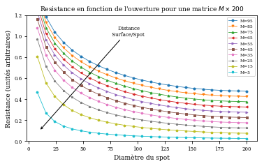

```python
FigAllRes=plt.figure(figsize=(15/2.54,(9/16)*(15/2.54)))
#def Reg(x, a, b):
#    return a/(x)

#ResReg=100/AllField[9]

#popt1, pcov1 = curve_fit(Reg, Size, ResReg)

#Axis=np.arange(3,200,1)
#Regression=popt1[0]/Axis
#plt.plot(Axis, Regression,color="grey",label="Regression")
plt.rc('text', usetex=False)
plt.rc('font', family='serif')

styl_list=['-','--','-.',':']
marker_list_full=['.', ',' ,'o','v','^','<','>','1','2','3','4','s','p','*','h','H','+','x','D','d','|','_']
marker_list=['o','v','^','<','>','s','p','*','h','H','+','x','D','d','|','_']
for i in np.arange(10):
    styl=styl_list[i %4]
    mark=marker_list[i]
    Res=100/AllField[i]
    plt.plot(Size,Res,label="M="+str(int(Height[i])),marker=mark,linewidth=0.8,markersize=3)
plt.ylim([0,1.2])
plt.legend()

plt.annotate("     Distance \n Surface/Spot",
            xy=(10, 0.1), xycoords='data', fontsize=7,
            xytext=(75, 1), textcoords='data',
            arrowprops=dict(arrowstyle="->",
                            connectionstyle="arc3"),
            )
plt.xlabel(r'Diamètre du spot',fontsize=9)
plt.ylabel(r'Resistance (unités arbitraires)',fontsize=9)
plt.title(r"Resistance en fonction de l'ouverture pour une matrice $M\times 200$",fontsize=9)
plt.legend(prop={'size': 6})
```

```python
FigAllRes.savefig('C:/Users/antoi/Documents/Stage_IKOS/Memoire/img/All_Res_200.eps')
```

```python
AllField[9]
```

```
array([ 215.47889625,  375.68360204,  535.68516457,  695.68517657,
        855.68517666, 1015.68517666, 1175.68517666, 1335.68517666,
       1495.68517666, 1655.68517666, 1815.68517666, 1975.68517666,
       2135.68517666, 2295.68517666, 2455.68517666, 2615.68517666,
       2775.68517664, 2935.68517625, 3095.68517004, 3255.68507159,
       3415.68350897, 3575.65870917, 3735.26585051, 3889.21575825,
       3999.9999999 ])
```

# Calcul résistance dans plusieurs ouvertures (Maille rectangulaire)

```python
N=10 # Nombre de ligne
M=120 # Nombre de colonne
V=np.zeros([N+1,M+1]) #Initialisation du réseau.
#V[1:99,1:99]=0.25*(V[2:100,1:99]+V[0:98,1:99]+V[1:99,2:100]+V[1:99,0:98])
#V[1:N-1,1:N-1]=0.25*(V[2:N,1:N-1]+V[0:N-2,1:N-1]+V[1:N-1,2:N]+V[1:N-1,0:N-2])
Scale=19
ParMaille=1#(N/M)**2
Eps= 1e-10
Ecart=1.0
i=np.arange(1,8)
Size=np.zeros(len(i))
Field=np.zeros(len(i))
while Ecart>Eps:
    Vprec=V.copy()
    V[N,:]=100 # Toutes les colonnes, et la ligne 99
    V[:,0]=V[:,1] #Bord Gauche
    V[:,M]=V[:,M-1] #Bord Droit

    V[1:N,1:M]=(1/(2*(ParMaille+1)))*(ParMaille*(V[2:N+1,1:M]+V[0:N-1,1:M])+V[1:N,2:M+1]+V[1:N,0:M-1])

    V[0,0:(30-Scale)]= V[1,0:(30-Scale)]
    V[0,(30+Scale):(90-Scale)]= V[1,(30+Scale):(90-Scale)]
    V[0,(90+Scale):M]= V[1,(90+Scale):M]
    Ecart = np.max(np.abs(V-Vprec))
```

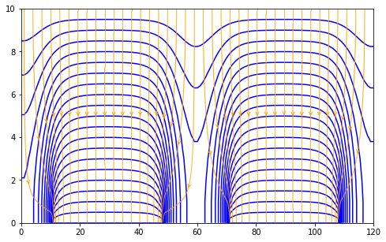

```python
x = np.arange(0,M+1,1)
y = np.arange(0,N+1,1)
X,Y = np.meshgrid(x,y)

A=np.linspace(1,M,40)
B = (N-1)*np.ones(len(A))
seed_points = np.array([A,B])


Ey,Ex = np.gradient(V)

Ey=-Ey
Ex=-Ex
plt.figure(figsize=(8,5))
plt.contour(X,Y,V,20,colors='b')
plt.streamplot(X, Y, Ex, Ey,linewidth=1,arrowstyle='->',density=10,start_points=seed_points.T,color='orange')
```

```python
np.sum(Ey[10,:])
```

```
-899.930781428071
```

```python
np.sum(Ey[0,(30-Scale):(30+Scale)])+np.sum(Ey[0,(90-Scale):(90+Scale)])
```

```
-893.7229102998323
```

# Test Influence

On va à present calculer la résistance de chacuns des spots : On va prendre un spot de taille fixe par exemple 5 et faire varier la distance entre les deux centres de chaque spot. A grande distance normalement aucune influence des spots et on va voir si en rapprochant les spots cela influe sur la résistance.  
Dans le code suivant, on va décaler le spot de sa propre taille. Par exemple un spot de taille 10, en premier il sera de 0 à 10, à l'étape d'après il sera de 10 à 20 etc.

```python
## Il faut encore faire le bon pas, ie la distance entre les trous dans l'algorithme


N=2 # Nombre de ligne
M=240 # Nombre de colonne
Scale=2 #Taille du spot
Shift=np.arange(0,int(M/(2*Scale)),1) # le -1 permet d'éviter le trou au milieu
# Facteur qui Permet de calculer le décalage des spots, à mettre en relation avec les conditions aux limites
#

EyInfluenceTot=np.zeros(len(Shift))
EyInfluenceTrou1=np.zeros(len(Shift))
EyInfluenceTrou2=np.zeros(len(Shift))

k=0

for n in Shift:
    N=2 # Nombre de ligne
    M=240 # Nombre de colonne
    V=np.zeros([N+1,M+1]) #Initialisation du réseau.
    ParMaille=1#(N/M)**2
    Eps= 1e-10
    Ecart=1.0
    i=np.arange(1,8)
    Size=np.zeros(len(i))
    Field=np.zeros(len(i))
    while Ecart>Eps:
        Vprec=V.copy()
        V[N,:]=100 # Toutes les colonnes, et la plus haute ligne
        V[:,0]=V[:,1] #Bord Gauche
        V[:,M]=V[:,M-1] #Bord Droit

        V[1:N,1:M]=(1/(2*(ParMaille+1)))*(ParMaille*(V[2:N+1,1:M]+V[0:N-1,1:M])+V[1:N,2:M+1]+V[1:N,0:M-1])

        #Conditions sur les plaques
        V[0,0:(0+n*Scale)]= V[1,0:(0+n*Scale)] # n doit commencer à 1 #Feuille avec calculs
        V[0,(Scale+n*Scale):(M-Scale-n*Scale)]= V[1,(Scale+n*Scale):(M-Scale-n*Scale)]
        V[0,(M-n*Scale):M]= V[1,(M-n*Scale):M]
        #Critère de convergence
        Ecart = np.max(np.abs(V-Vprec))
    Ey,Ex = np.gradient(V)
    EyInfluenceTot[k]=np.sum(Ey[N,:])
    EyInfluenceTrou1[k]=np.sum(Ey[0,n*Scale:(n+1)*Scale])
    EyInfluenceTrou2[k]=np.sum(Ey[0,M-(n+1)*Scale:M-n*Scale])
    k=k+1
```

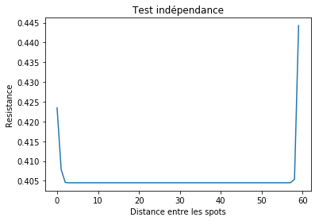

```python
Res=100/(EyInfluenceTrou1+EyInfluenceTrou2)
plt.plot(Shift,Res)
plt.xlabel("Distance entre les spots")
plt.ylabel("Resistance")
plt.title("Test indépendance")
```

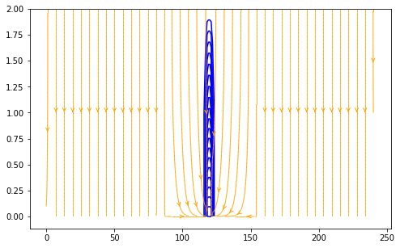

```python
x = np.arange(0,M+1,1)
y = np.arange(0,N+1,1)
X,Y = np.meshgrid(x,y)

A=np.linspace(1,M,40)
B = (N-1)*np.ones(len(A))
seed_points = np.array([A,B])


Ey,Ex = np.gradient(V)

Ey=-Ey
Ex=-Ex
plt.figure(figsize=(8,5))
plt.contour(X,Y,V,20,colors='b')
plt.streamplot(X, Y, Ex, Ey,linewidth=1,arrowstyle='->',density=10,start_points=seed_points.T,color='orange')
```

# Plus précis au niveau des trous, pas plus fin au niveau du décalage pour deux spots

Dans cette partie on va choisir deux spots chacun à l'extremité de la grille (i.e. un spot completement à gauche et completement à droite, et on va peu à peu les rapprocher ( avec un pas de 1 ici). A chaque pas on va calculer le flux passant à travers chacun des spots. On va alors sommer ces deux flux, et on va calculer la résistance en chaque point que l'on va ensuite representer dans un graphique. Si la courbe contient une partie constance, cela signifiera que sur cette dernière la resitance n'est pas une fonciton de la distance entre les spots.

```python
N=2 # Nombre de ligne
M=240 # Nombre de colonne
Scale=2 #Taille du spot
Shift=np.arange(1,int(M/2 - Scale),1) # le -1 permet d'éviter le trou au milieu

EyInfluenceTot=np.zeros(len(Shift))
EyInfluenceTrou1=np.zeros(len(Shift))
EyInfluenceTrou2=np.zeros(len(Shift))

k=0

for n in Shift:
    N=2 # Nombre de ligne
    M=240 # Nombre de colonne
    V=np.zeros([N+1,M+1]) #Initialisation du réseau.
    ParMaille=1#(N/M)**2
    Eps= 1e-10
    Ecart=1.0
    i=np.arange(1,8)
    Size=np.zeros(len(i))
    Field=np.zeros(len(i))
    while Ecart>Eps:
        Vprec=V.copy()
        V[N,:]=100 # Toutes les colonnes, et la ligne 99
        V[:,0]=V[:,1] #Bord Gauche
        V[:,M]=V[:,M-1] #Bord Droit

        V[1:N,1:M]=(1/(2*(ParMaille+1)))*(ParMaille*(V[2:N+1,1:M]+V[0:N-1,1:M])+V[1:N,2:M+1]+V[1:N,0:M-1])

        V[0,0:n]= V[1,0:n] #n doit commencer à 1
        V[0,Scale+n:M-Scale-n]= V[1,Scale+n:M-Scale-n]
        V[0,M-n:M]= V[1,M-n:M]
        Ecart = np.max(np.abs(V-Vprec))
    Ey,Ex = np.gradient(V)
    EyInfluenceTot[k]=np.sum(Ey[N,:])
    EyInfluenceTrou1[k]=np.sum(Ey[0,n:n+Scale])
    EyInfluenceTrou2[k]=np.sum(Ey[0,M-n-Scale:M-n])
    k=k+1
```

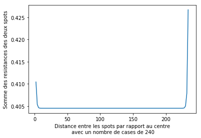

```python
Res=100/(EyInfluenceTrou1+EyInfluenceTrou2)
DistDeuxSpots=np.flip(np.arange(2,M-2*Scale,2))
plt.plot(DistDeuxSpots,Res)
plt.xlabel("Distance entre les spots par rapport au centre\n avec un nombre de cases de "+str(M))
plt.ylabel("Somme des resistances des deux spots")
```

Comme la somme est constante sur une grande partie de la courbe, cela veut dire que la distance entre les spots ne joue pas de rôle dans la résistance totale des deux spots. On peut alors considerer que dans ce cas numérique il y a independance des spots (On peut aussi traduire cela par le fait qu'ils sont associés en parallèle). On suppose que les grande pente sur la droite et la gauche de la courbe sont dûs aux effets de bord de la simulation, en effet comme on a imposé des conditions de Neumann cela peut poser problème.

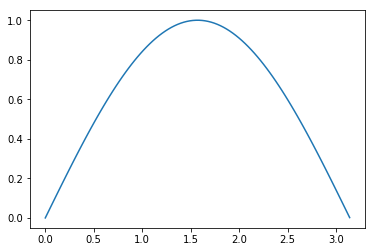

```python
x=np.linspace(0,3.14,100)
y=np.sin(x)
plt.plot(x,y)
```

# Trois Spots

```python
N=2 # Nombre de ligne
M=120 # Nombre de colonne
V=np.zeros([N+1,M+1]) #Initialisation du réseau.
#V[1:99,1:99]=0.25*(V[2:100,1:99]+V[0:98,1:99]+V[1:99,2:100]+V[1:99,0:98])
#V[1:N-1,1:N-1]=0.25*(V[2:N,1:N-1]+V[0:N-2,1:N-1]+V[1:N-1,2:N]+V[1:N-1,0:N-2])
n=5
Scale=19
ParMaille=1#(N/M)**2
Eps= 1e-10
Ecart=1.0
i=np.arange(1,8)
Size=np.zeros(len(i))
Field=np.zeros(len(i))
while Ecart>Eps:
    Vprec=V.copy()
    V[N,:]=100 # Toutes les colonnes, et la ligne 99
    V[:,0]=V[:,1] #Bord Gauche
    V[:,M]=V[:,M-1] #Bord Droit

    V[1:N,1:M]=(1/(2*(ParMaille+1)))*(ParMaille*(V[2:N+1,1:M]+V[0:N-1,1:M])+V[1:N,2:M+1]+V[1:N,0:M-1])

    V[0,0:n]= V[1,0:n] #n doit commencer à 1
    V[0,Scale+n:int(M/2)-int(Scale/2)]= V[1,Scale+n:int(M/2)-int(Scale/2)]
    V[0,int(M/2)+int(Scale/2):M-Scale-n]= V[1,int(M/2)+int(Scale/2):M-Scale-n]
    V[0,M-n:M]= V[1,M-n:M]
    Ecart = np.max(np.abs(V-Vprec))
```

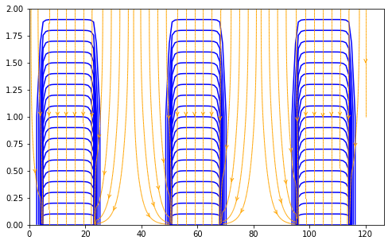

```python
x = np.arange(0,M+1,1)
y = np.arange(0,N+1,1)
X,Y = np.meshgrid(x,y)

A=np.linspace(1,M,40)
B = (N-1)*np.ones(len(A))
seed_points = np.array([A,B])


Ey,Ex = np.gradient(V)

Ey=-Ey
Ex=-Ex
plt.figure(figsize=(8,5))
plt.contour(X,Y,V,20,colors='b')
plt.streamplot(X, Y, Ex, Ey,linewidth=1,arrowstyle='->',density=10,start_points=seed_points.T,color='orange')
```

# Boucle pour trois spots

```python
N=2 # Nombre de ligne
M=240 # Nombre de colonne
Scale=2 #Taille du spot
Shift=np.arange(1,int(M/2 - Scale -int(Scale/2)-1),1) # le -1 permet d'éviter le trou au milieu -int(Scale/2) prend en compte celui du  milieu

EyInfluenceTot=np.zeros(len(Shift))
EyInfluenceTrou1=np.zeros(len(Shift))
EyInfluenceTrou2=np.zeros(len(Shift))
EyInfluenceTrouMid=np.zeros(len(Shift))

k=0

for n in Shift:
    N=2 # Nombre de ligne
    M=240 # Nombre de colonne
    V=np.zeros([N+1,M+1]) #Initialisation du réseau.
    ParMaille=1#(N/M)**2
    Eps= 1e-10
    Ecart=1.0
    i=np.arange(1,8)
    Size=np.zeros(len(i))
    Field=np.zeros(len(i))
    while Ecart>Eps:
        Vprec=V.copy()
        V[N,:]=100 # Toutes les colonnes, et la ligne 99
        V[:,0]=V[:,1] #Bord Gauche
        V[:,M]=V[:,M-1] #Bord Droit

        V[1:N,1:M]=(1/(2*(ParMaille+1)))*(ParMaille*(V[2:N+1,1:M]+V[0:N-1,1:M])+V[1:N,2:M+1]+V[1:N,0:M-1])

        #Conditions de Neumann à droite et à gauche des spots.
        V[0,0:n]= V[1,0:n] #n doit commencer à 1
        V[0,Scale+n:int(M/2)-int(Scale/2)]= V[1,Scale+n:int(M/2)-int(Scale/2)]
        V[0,int(M/2)+int(Scale/2):M-Scale-n]= V[1,int(M/2)+int(Scale/2):M-Scale-n]
        V[0,M-n:M]= V[1,M-n:M]

        Ecart = np.max(np.abs(V-Vprec))
    Ey,Ex = np.gradient(V)
    EyInfluenceTot[k]=np.sum(Ey[N,:])
    EyInfluenceTrou1[k]=np.sum(Ey[0,n:n+Scale])
    EyInfluenceTrou2[k]=np.sum(Ey[0,M-n-Scale:M-n])
    EyInfluenceTrouMid[k]=np.sum(Ey[0,int(M/2)-int(Scale/2):int(M/2)+int(Scale/2)])

    k=k+1
```

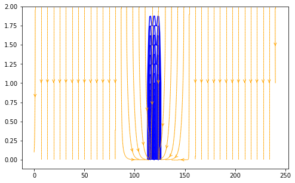

```python
x = np.arange(0,M+1,1)
y = np.arange(0,N+1,1)
X,Y = np.meshgrid(x,y)

A=np.linspace(1,M,40)
B = (N-1)*np.ones(len(A))
seed_points = np.array([A,B])


Ey,Ex = np.gradient(V)

Ey=-Ey
Ex=-Ex
plt.figure(figsize=(8,5))
plt.contour(X,Y,V,20,colors='b')
plt.streamplot(X, Y, Ex, Ey,linewidth=1,arrowstyle='->',density=10,start_points=seed_points.T,color='orange')
```

[figure not shown]

```python
Res=100/(EyInfluenceTrou1+EyInfluenceTrou2+EyInfluenceTrouMid)
DistDeuxSpots=np.flip(np.arange(2,int(M/2 - Scale/2)-Scale,1))
plt.plot(DistDeuxSpots,Res)
plt.xlabel("Distance entre le bord droit du spot tout à gauche\n et le bord gauche du spot au milieu\n avec un nombre de cases de "+str(M))
plt.ylabel("Somme des resistances des deux spots")
plt.title("Influence résistance 3 spots")
```

# Plot figure resistance + Lignes (Compiler code au dessus avant)

```python
N=20 # Nombre de ligne
M=240 # Nombre de colonne
Scale2=20 #Taille du spot
Shift2=np.arange(1,int(M/2 - Scale2 -int(Scale2/2)-1),1) # le -1 permet d'éviter le trou au milieu -int(Scale/2) prend en compte celui du  milieu

n2=30
k=0

N=20 # Nombre de ligne
M=240 # Nombre de colonne
V=np.zeros([N+1,M+1]) #Initialisation du réseau.
ParMaille=1#(N/M)**2
Eps= 1e-10
Ecart=1.0
i=np.arange(1,8)
Size=np.zeros(len(i))
Field=np.zeros(len(i))
while Ecart>Eps:
    Vprec=V.copy()
    V[N,:]=100 # Toutes les colonnes, et la ligne 99
    V[:,0]=V[:,1] #Bord Gauche
    V[:,M]=V[:,M-1] #Bord Droit

    V[1:N,1:M]=(1/(2*(ParMaille+1)))*(ParMaille*(V[2:N+1,1:M]+V[0:N-1,1:M])+V[1:N,2:M+1]+V[1:N,0:M-1])

    V[0,0:n2]= V[1,0:n2] #n doit commencer à 1
    V[0,Scale2+n2:int(M/2)-int(Scale2/2)]= V[1,Scale2+n2:int(M/2)-int(Scale2/2)]
    V[0,int(M/2)+int(Scale2/2):M-Scale2-n2]= V[1,int(M/2)+int(Scale2/2):M-Scale2-n2]
    V[0,M-n2:M]= V[1,M-n2:M]
    Ecart = np.max(np.abs(V-Vprec))

k=k+1
```

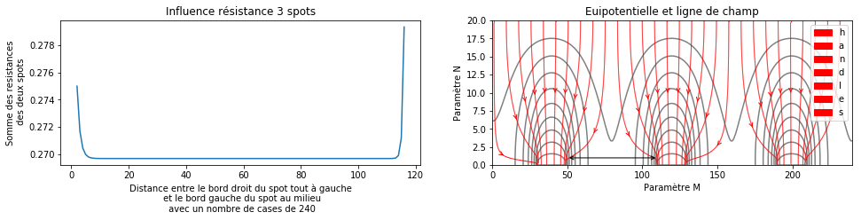

```python
x = np.arange(0,M+1,1)
y = np.arange(0,N+1,1)
X,Y = np.meshgrid(x,y)
A=np.linspace(1,M,30)
B = (N-1)*np.ones(len(A))
seed_points = np.array([A,B])
Ey,Ex = np.gradient(V)
Ey=-Ey
Ex=-Ex

Res=100/(EyInfluenceTrou1+EyInfluenceTrou2+EyInfluenceTrouMid)
DistDeuxSpots=np.flip(np.arange(2,int(M/2 - Scale/2)-Scale,1))

plt.figure(figsize=(16,3))
ax1=plt.subplot(121)
ax1.plot(DistDeuxSpots,Res)
ax1.set_xlabel("Distance entre le bord droit du spot tout à gauche\n et le bord gauche du spot au milieu\n avec un nombre de cases de "+str(M))
ax1.set_ylabel("Somme des resistances\n des deux spots")
ax1.set_title("Influence résistance 3 spots")
ax2=plt.subplot(122)
ax2.contour(X,Y,V,10,colors='grey')
ax2.streamplot(X, Y, Ex, Ey,linewidth=1,arrowstyle='->',density=10,start_points=seed_points.T,color='red')
ax2.set_xlabel("Paramètre M")
ax2.set_ylabel("Paramètre N")
ax2.set_title("Euipotentielle et ligne de champ")
ax2.legend("handles")
plt.annotate("",
            xy=(50, 1), xycoords='data',
            xytext=(110, 1), textcoords='data',
            arrowprops=dict(arrowstyle="<->",
                            connectionstyle="arc3"),
            )
```

```python
EyInfluenceTrou1[20]
```

```
123.6067977499434
```

```python
EyInfluenceTrou2[20]
```

```
123.6067977499434
```

```python
EyInfluenceTrouMid[20]
```

```
123.6067977499434
```

# Plot avec potentiel non nul sur les plaques

```python
N=20 # Nombre de ligne
M=240 # Nombre de colonne
Scale=20 #Taille du spot
Shift=np.arange(1,int(M/2 - Scale),1) # le -1 permet d'éviter le trou au milieu

n=20

V=np.zeros([N+1,M+1]) #Initialisation du réseau.
ParMaille=1#(N/M)**2
Eps= 1e-10
Ecart=1.0
i=np.arange(1,8)
Size=np.zeros(len(i))
Field=np.zeros(len(i))
while Ecart>Eps:
    Vprec=V.copy()
    V[N,:]=100 # Toutes les colonnes, et la ligne 99
    V[:,0]=V[:,1] #Bord Gauche
    V[:,M]=V[:,M-1] #Bord Droit

    V[1:N,1:M]=(1/(2*(ParMaille+1)))*(ParMaille*(V[2:N+1,1:M]+V[0:N-1,1:M])+V[1:N,2:M+1]+V[1:N,0:M-1])

    #Conditions de Neumann à droite et à gauche des spots.

    #Remet potentiel nul avant conditions de Neumann( Commme on met un potentiel non nul sur les plaques et qu'on décale)
    V[0,0:n]= 0 #n doit commencer à 1
    V[0,Scale+n:M-Scale-n]= 0
    V[0,M-n:M]= 0

    #Neumann
    V[0,0:n]= V[1,0:n] #n doit commencer à 1
    V[0,Scale+n:M-Scale-n]= V[1,Scale+n:M-Scale-n]
    V[0,M-n:M]= V[1,M-n:M]

    #Potentiel non nul sur les spots
    V[0,n:Scale+n]= 80
    V[0,M-Scale-n:M-n]= 80

    Ecart = np.max(np.abs(V-Vprec))
```

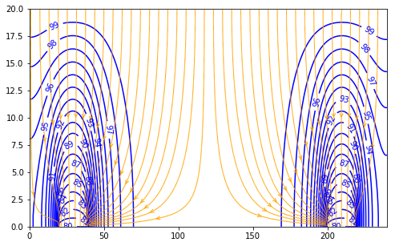

```python
x = np.arange(0,M+1,1)
y = np.arange(0,N+1,1)
X,Y = np.meshgrid(x,y)

A=np.linspace(1,M,40)
B = (N-1)*np.ones(len(A))
seed_points = np.array([A,B])


Ey,Ex = np.gradient(V)

Ey=-Ey
Ex=-Ex
plt.figure(figsize=(8,5))
equ=plt.contour(X,Y,V,20,colors='b')
plt.clabel(equ, fontsize=10, inline=1,fmt='%1.0f')
plt.streamplot(X, Y, Ex, Ey,linewidth=1,arrowstyle='->',density=10,start_points=seed_points.T,color='orange')
```

# Mettre potentiel non nul sur les spots boucle

```python
N=2 # Nombre de ligne
M=240 # Nombre de colonne
Scale=2 #Taille du spot
Shift=np.arange(1,int(M/2 - Scale),1) # le -1 permet d'éviter le trou au milieu

EyInfluenceTot=np.zeros(len(Shift))
EyInfluenceTrou1=np.zeros(len(Shift))
EyInfluenceTrou2=np.zeros(len(Shift))

k=0

for n in Shift:
    N=2 # Nombre de ligne
    M=240 # Nombre de colonne
    V=np.zeros([N+1,M+1]) #Initialisation du réseau.
    ParMaille=1#(N/M)**2
    Eps= 1e-10
    Ecart=1.0
    i=np.arange(1,8)
    Size=np.zeros(len(i))
    Field=np.zeros(len(i))
    while Ecart>Eps:
        Vprec=V.copy()
        V[N,:]=100 # Toutes les colonnes, et la ligne 99
        V[:,0]=V[:,1] #Bord Gauche
        V[:,M]=V[:,M-1] #Bord Droit

        V[1:N,1:M]=(1/(2*(ParMaille+1)))*(ParMaille*(V[2:N+1,1:M]+V[0:N-1,1:M])+V[1:N,2:M+1]+V[1:N,0:M-1])

        #Conditions de Neumann à droite et à gauche des spots.

        #Remet potentiel nul avant conditions de Neumann( Commme on met un potentiel non nul sur les plaques et qu'on décale)
        V[0,0:n]= 0 #n doit commencer à 1
        V[0,Scale+n:M-Scale-n]= 0
        V[0,M-n:M]= 0

        #Neumann
        V[0,0:n]= V[1,0:n] #n doit commencer à 1
        V[0,Scale+n:M-Scale-n]= V[1,Scale+n:M-Scale-n]
        V[0,M-n:M]= V[1,M-n:M]

        #Potentiel non nul sur les spots
        V[0,n:Scale+n]= 80
        V[0,M-Scale-n:M-n]= 80

        Ecart = np.max(np.abs(V-Vprec))

    Ey,Ex = np.gradient(V)
    EyInfluenceTot[k]=np.sum(Ey[N,:])
    EyInfluenceTrou1[k]=np.sum(Ey[0,n:n+Scale])
    EyInfluenceTrou2[k]=np.sum(Ey[0,M-n-Scale:M-n])
    k=k+1
```

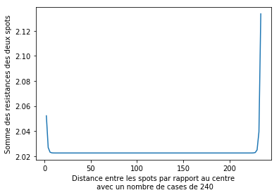

```python
Res=100/(EyInfluenceTrou1+EyInfluenceTrou2)
DistDeuxSpots=np.flip(np.arange(2,M-2*Scale,2))
plt.plot(DistDeuxSpots,Res)
plt.xlabel("Distance entre les spots par rapport au centre\n avec un nombre de cases de "+str(M))
plt.ylabel("Somme des resistances des deux spots")
```

On voit alors que le fait d'imposer un potentiel ne change pas l'indépendance des spots.

# Deux Spots de taille différentes

```python
N=40 # Nombre de ligne
M=240 # Nombre de colonne
Scale=40 #Taille du spot
Shift=np.arange(1,int(M/2 - Scale),1) # le -1 permet d'éviter le trou au milieu

n=40

V=np.zeros([N+1,M+1]) #Initialisation du réseau.
ParMaille=1#(N/M)**2
Eps= 1e-10
Ecart=1.0
i=np.arange(1,8)
Size=np.zeros(len(i))
Field=np.zeros(len(i))
while Ecart>Eps:
    Vprec=V.copy()
    V[N,:]=100 # Toutes les colonnes, et la ligne 99
    V[:,0]=V[:,1] #Bord Gauche
    V[:,M]=V[:,M-1] #Bord Droit

    V[1:N,1:M]=(1/(2*(ParMaille+1)))*(ParMaille*(V[2:N+1,1:M]+V[0:N-1,1:M])+V[1:N,2:M+1]+V[1:N,0:M-1])

    #Conditions de Neumann à droite et à gauche des spots.
    #Neumann
    V[0,0:n]= V[1,0:n] #n doit commencer à 1
    V[0,Scale+n+5:M-Scale-n]= V[1,Scale+n+5:M-Scale-n]
    V[0,M-n:M]= V[1,M-n:M]

    #Potentiel non nul sur les spots

    Ecart = np.max(np.abs(V-Vprec))
```

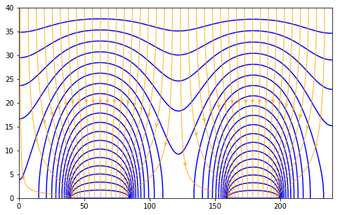

```python
x = np.arange(0,M+1,1)
y = np.arange(0,N+1,1)
X,Y = np.meshgrid(x,y)

A=np.linspace(1,M,40)
B = (N-1)*np.ones(len(A))
seed_points = np.array([A,B])


Ey,Ex = np.gradient(V)

Ey=-Ey
Ex=-Ex
plt.figure(figsize=(8,5))
equ=plt.contour(X,Y,V,20,colors='b')
#plt.clabel(equ, fontsize=10, inline=1,fmt='%1.0f')
plt.streamplot(X, Y, Ex, Ey,linewidth=1,arrowstyle='->',density=10,start_points=seed_points.T,color='orange')
```

# Influence dans le cas de deux spots de taille différente

```python
N=2 # Nombre de ligne
M=240 # Nombre de colonne
Scale=20 #Taille du spot
Shift=np.arange(1,int(M/2 - Scale)-20,1) # le -1 permet d'éviter le trou au milieu

EyInfluenceTot=np.zeros(len(Shift))
EyInfluenceTrou1=np.zeros(len(Shift))
EyInfluenceTrou2=np.zeros(len(Shift))

k=0

for n in Shift:
    N=2 # Nombre de ligne
    M=240 # Nombre de colonne
    V=np.zeros([N+1,M+1]) #Initialisation du réseau.
    ParMaille=1#(N/M)**2
    Eps= 1e-10
    Ecart=1.0
    i=np.arange(1,8)
    Size=np.zeros(len(i))
    Field=np.zeros(len(i))
    while Ecart>Eps:
        Vprec=V.copy()
        V[N,:]=100 # Toutes les colonnes, et la ligne 99
        V[:,0]=V[:,1] #Bord Gauche
        V[:,M]=V[:,M-1] #Bord Droit

        V[1:N,1:M]=(1/(2*(ParMaille+1)))*(ParMaille*(V[2:N+1,1:M]+V[0:N-1,1:M])+V[1:N,2:M+1]+V[1:N,0:M-1])

        #Conditions de Neumann à droite et à gauche des spots.

        #Neumann
        V[0,0:n]= V[1,0:n] #n doit commencer à 1
        V[0,Scale+n+40:M-Scale-n]= V[1,Scale+n+40:M-Scale-n]
        V[0,M-n:M]= V[1,M-n:M]


        Ecart = np.max(np.abs(V-Vprec))

    Ey,Ex = np.gradient(V)
    EyInfluenceTot[k]=np.sum(Ey[N,:])
    EyInfluenceTrou1[k]=np.sum(Ey[0,n:n+Scale+40])
    EyInfluenceTrou2[k]=np.sum(Ey[0,M-n-Scale:M-n])
    k=k+1
```

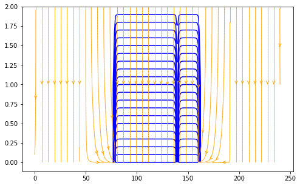

```python
x = np.arange(0,M+1,1)
y = np.arange(0,N+1,1)
X,Y = np.meshgrid(x,y)

A=np.linspace(1,M,40)
B = (N-1)*np.ones(len(A))
seed_points = np.array([A,B])


Ey,Ex = np.gradient(V)

Ey=-Ey
Ex=-Ex
plt.figure(figsize=(8,5))
equ=plt.contour(X,Y,V,20,colors='b')
#plt.clabel(equ, fontsize=10, inline=1,fmt='%1.0f')
plt.streamplot(X, Y, Ex, Ey,linewidth=1,arrowstyle='->',density=10,start_points=seed_points.T,color='orange')
```

```python
np.sum(Ey[0,n:n+Scale+40])
np.sum(Ey[0,M-n-Scale:M-n])
Ey[0,140:162]
```

```
array([ -0.        , -57.73502692, -52.07259422, -50.55534995,
       -50.14880558, -50.03987236, -50.01068385, -50.00286304,
       -50.00076832, -50.00021025, -50.00007267, -50.00008043,
       -50.00024906, -50.00091579, -50.00341411, -50.01274065,
       -50.04754847, -50.17745324, -50.66226449, -52.47160472,
       -59.22415441,  -0.        ])
```

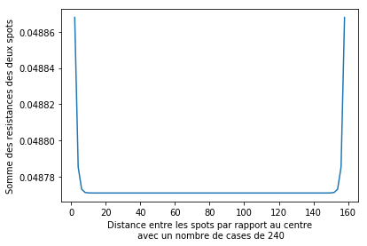

```python
Res=100/(EyInfluenceTrou2+EyInfluenceTrou2)
DistDeuxSpots=np.flip(np.arange(2,M-2*Scale-40,2))
plt.plot(DistDeuxSpots,Res)
plt.xlabel("Distance entre les spots par rapport au centre\n avec un nombre de cases de "+str(M))
plt.ylabel("Somme des resistances des deux spots")
```

# Influence dans le cas de deux spots de taille différente mais décalé par rapport au centre (Test Symétrie)

```python
N=2 # Nombre de ligne
M=240 # Nombre de colonne
Scale=20 #Taille du spot
Shift=np.arange(1,int(M/2 - Scale)-40,1) # le -1 permet d'éviter le trou au milieu

EyInfluenceTot=np.zeros(len(Shift))
EyInfluenceTrou1=np.zeros(len(Shift))
EyInfluenceTrou2=np.zeros(len(Shift))

k=0

for n in Shift:
    N=2 # Nombre de ligne
    M=240 # Nombre de colonne
    V=np.zeros([N+1,M+1]) #Initialisation du réseau.
    ParMaille=1#(N/M)**2
    Eps= 1e-10
    Ecart=1.0
    i=np.arange(1,8)
    Size=np.zeros(len(i))
    Field=np.zeros(len(i))
    while Ecart>Eps:
        Vprec=V.copy()
        V[N,:]=100 # Toutes les colonnes, et la ligne 99
        V[:,0]=V[:,1] #Bord Gauche
        V[:,M]=V[:,M-1] #Bord Droit

        V[1:N,1:M]=(1/(2*(ParMaille+1)))*(ParMaille*(V[2:N+1,1:M]+V[0:N-1,1:M])+V[1:N,2:M+1]+V[1:N,0:M-1])

        #Conditions de Neumann à droite et à gauche des spots.

        #Neumann
        V[0,0:n+40]= V[1,0:n+40] #n doit commencer à 1
        V[0,Scale+n+80:M-Scale-n]= V[1,Scale+n+80:M-Scale-n]
        V[0,M-n:M]= V[1,M-n:M]


        Ecart = np.max(np.abs(V-Vprec))

    Ey,Ex = np.gradient(V)
    EyInfluenceTot[k]=np.sum(Ey[N,:])
    EyInfluenceTrou1[k]=np.sum(Ey[0,n+40:n+Scale+80])
    EyInfluenceTrou2[k]=np.sum(Ey[0,M-n-Scale:M-n])
    k=k+1
```

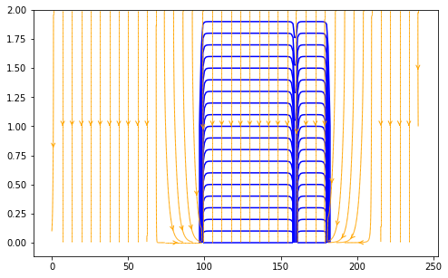

```python
x = np.arange(0,M+1,1)
y = np.arange(0,N+1,1)
X,Y = np.meshgrid(x,y)

A=np.linspace(1,M,40)
B = (N-1)*np.ones(len(A))
seed_points = np.array([A,B])


Ey,Ex = np.gradient(V)

Ey=-Ey
Ex=-Ex
plt.figure(figsize=(8,5))
equ=plt.contour(X,Y,V,20,colors='b')
#plt.clabel(equ, fontsize=10, inline=1,fmt='%1.0f')
plt.streamplot(X, Y, Ex, Ey,linewidth=1,arrowstyle='->',density=10,start_points=seed_points.T,color='orange')
```

```python
Ey[0,n+0:n+Scale+83]
Ey[0,M-n-Scale-1:M-n-1]
```

```
array([ -0.        , -57.73502692, -52.07259422, -50.55534995,
       -50.14880558, -50.03987236, -50.01068385, -50.00286304,
       -50.00076832, -50.00021025, -50.00007267, -50.00008043,
       -50.00024906, -50.00091579, -50.00341411, -50.01274065,
       -50.04754847, -50.17745324, -50.66226449, -52.47160472])
```

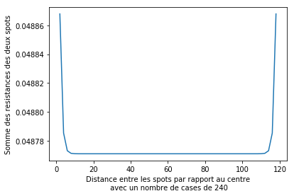

```python
Res=100/(EyInfluenceTrou2+EyInfluenceTrou2)
DistDeuxSpots=np.flip(np.arange(2,M-2*Scale-80,2))
plt.plot(DistDeuxSpots,Res)
plt.xlabel("Distance entre les spots par rapport au centre\n avec un nombre de cases de "+str(M))
plt.ylabel("Somme des resistances des deux spots")
```

# Deux Spots identiques calcul dépendance, mais avec potentiel différent.

Aussi on peut écrire un matrice de resistance qui va mesurer l'indépendance ou la dépendance des spots :

```python
N=2 # Nombre de ligne
M=240 # Nombre de colonne
Scale=2 #Taille du spot
Shift=np.arange(1,int(M/2 - Scale),1) # le -1 permet d'éviter le trou au milieu

EyInfluenceTot=np.zeros(len(Shift))
EyInfluenceTrou1=np.zeros(len(Shift))
EyInfluenceTrou2=np.zeros(len(Shift))

k=0

#Test n fixe
Fixe=[1,40]
for n in Shift:
    N=20 # Nombre de ligne
    M=240 # Nombre de colonne
    V=np.zeros([N+1,M+1]) #Initialisation du réseau.
    ParMaille=1#(N/M)**2
    Eps= 1e-10
    Ecart=1.0
    i=np.arange(1,8)
    Size=np.zeros(len(i))
    Field=np.zeros(len(i))
    while Ecart>Eps:
        Vprec=V.copy()
        V[N,:]=100 # Toutes les colonnes, et la ligne 99
        V[:,0]=V[:,1] #Bord Gauche
        V[:,M]=V[:,M-1] #Bord Droit

        V[1:N,1:M]=(1/(2*(ParMaille+1)))*(ParMaille*(V[2:N+1,1:M]+V[0:N-1,1:M])+V[1:N,2:M+1]+V[1:N,0:M-1])

        #Conditions de Neumann à droite et à gauche des spots.

        #Remet potentiel nul avant conditions de Neumann( Commme on met un potentiel non nul sur les plaques et qu'on décale)
        V[0,0:n]= 0 #n doit commencer à 1
        V[0,Scale+n:M-Scale-n]= 0
        V[0,M-n:M]= 0

        #Neumann
        V[0,0:n]= V[1,0:n] #n doit commencer à 1
        V[0,Scale+n:M-Scale-n]= V[1,Scale+n:M-Scale-n]
        V[0,M-n:M]= V[1,M-n:M]

        #Potentiel non nul sur les spots
        V[0,n:Scale+n]= 10
        V[0,M-Scale-n:M-n]= 20

        Ecart = np.max(np.abs(V-Vprec))

    Ey,Ex = np.gradient(V)
    EyInfluenceTot[k]=np.sum(Ey[N,:])
    EyInfluenceTrou1[k]=np.sum(Ey[0,n:n+Scale])
    EyInfluenceTrou2[k]=np.sum(Ey[0,M-n-Scale:M-n])
    k=k+1
```

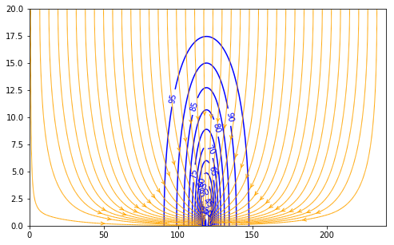

```python
x = np.arange(0,M+1,1)
y = np.arange(0,N+1,1)
X,Y = np.meshgrid(x,y)

A=np.linspace(1,M,40)
B = (N-1)*np.ones(len(A))
seed_points = np.array([A,B])


Ey,Ex = np.gradient(V)

Ey=-Ey
Ex=-Ex
plt.figure(figsize=(8,5))
equ=plt.contour(X,Y,V,20,colors='b')
plt.clabel(equ, fontsize=10, inline=1,fmt='%1.0f')
plt.streamplot(X, Y, Ex, Ey,linewidth=1,arrowstyle='->',density=10,start_points=seed_points.T,color='orange')
```

```python
90/(EyInfluenceTrou1)+80/(EyInfluenceTrou2)
```

[output not shown]

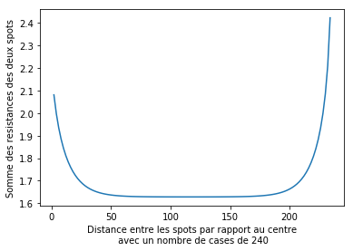

```python
Res=90/(EyInfluenceTrou1)+80/(EyInfluenceTrou2)
DistDeuxSpots=np.flip(np.arange(2,M-2*Scale,2))
plt.plot(DistDeuxSpots,Res)
plt.xlabel("Distance entre les spots par rapport au centre\n avec un nombre de cases de "+str(M))
plt.ylabel("Somme des resistances des deux spots")
```

# Deux Spots taille différentes calcul dépendance, mais avec potentiel différent.

```python
N=2 # Nombre de ligne
M=240 # Nombre de colonne
Scale=10 #Taille du spot
Shift=np.arange(1,int(M/2 - Scale)-20,1) # le -1 permet d'éviter le trou au milieu

EyInfluenceTot=np.zeros(len(Shift))
EyInfluenceTrou1=np.zeros(len(Shift))
EyInfluenceTrou2=np.zeros(len(Shift))

k=0

for n in Shift:
    N=2 # Nombre de ligne
    M=240 # Nombre de colonne
    V=np.zeros([N+1,M+1]) #Initialisation du réseau.
    ParMaille=1#(N/M)**2
    Eps= 1e-10
    Ecart=1.0
    i=np.arange(1,8)
    Size=np.zeros(len(i))
    Field=np.zeros(len(i))
    while Ecart>Eps:
        Vprec=V.copy()
        V[N,:]=100 # Toutes les colonnes, et la ligne 99
        V[:,0]=V[:,1] #Bord Gauche
        V[:,M]=V[:,M-1] #Bord Droit


        V[1:N,1:M]=(1/(2*(ParMaille+1)))*(ParMaille*(V[2:N+1,1:M]+V[0:N-1,1:M])+V[1:N,2:M+1]+V[1:N,0:M-1])

        #Conditions de Neumann à droite et à gauche des spots.

        #Neumann
        V[0,0:n]= V[1,0:n] #n doit commencer à 1
        V[0,Scale+n+40:M-Scale-n]= V[1,Scale+n+40:M-Scale-n]
        V[0,M-n:M]= V[1,M-n:M]

        V[0,n:Scale+n+40]= 50
        V[0,M-Scale-n:M-n]= 80

        Ecart = np.max(np.abs(V-Vprec))

    Ey,Ex = np.gradient(V)
    EyInfluenceTot[k]=np.sum(Ey[N,:])
    EyInfluenceTrou1[k]=np.sum(Ey[0,n:n+Scale+40])
    EyInfluenceTrou2[k]=np.sum(Ey[0,M-n-Scale:M-n])
    k=k+1
```

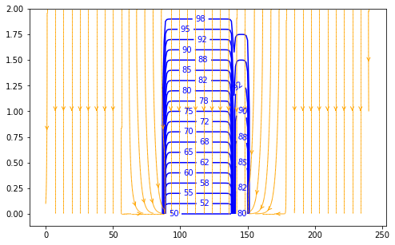

```python
x = np.arange(0,M+1,1)
y = np.arange(0,N+1,1)
X,Y = np.meshgrid(x,y)

A=np.linspace(1,M,40)
B = (N-1)*np.ones(len(A))
seed_points = np.array([A,B])


Ey,Ex = np.gradient(V)

Ey=-Ey
Ex=-Ex
plt.figure(figsize=(8,5))
equ=plt.contour(X,Y,V,20,colors='b')
plt.clabel(equ, fontsize=10, inline=1,fmt='%1.0f')
plt.streamplot(X, Y, Ex, Ey,linewidth=1,arrowstyle='->',density=10,start_points=seed_points.T,color='orange')
```

```python
Ey[0,:]
```

[output not shown]

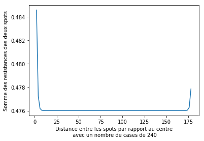

```python
Res=100/(EyInfluenceTrou2+EyInfluenceTrou2)
DistDeuxSpots=np.flip(np.arange(2,M-2*Scale-40,2))
plt.plot(DistDeuxSpots,Res)
plt.xlabel("Distance entre les spots par rapport au centre\n avec un nombre de cases de "+str(M))
plt.ylabel("Somme des resistances des deux spots")
```